# Risk Factor Analysis

## Outcome Variable

**Outcome Variable:** ever_wasted

## Predictor Variables

**Intervention Variable:** exclfeed6

**Adjustment Set:**

- arm
- sex
- brthmon
- W_mage
- meducyrs
- feducyrs
- hhwealth_quart
- hfoodsec
- W_mhtcm
- W_mwtkg
- W_mbmi
- vagbrth
- W_gagebrth
- W_birthwt
- W_birthlen
- W_nrooms
- W_nchldlt5
- month
- W_parity
- impfloor
- impsan
- safeh20
- delta_W_mage
- delta_meducyrs
- delta_feducyrs
- delta_hhwealth_quart
- delta_hfoodsec
- delta_W_mhtcm
- delta_W_mwtkg
- delta_W_mbmi
- delta_vagbrth
- delta_W_gagebrth
- delta_W_birthwt
- delta_W_birthlen
- delta_W_nrooms
- delta_W_nchldlt5
- delta_month
- delta_W_parity
- delta_impfloor
- delta_impsan
- delta_safeh20

## Stratifying Variables

The analysis was stratified on these variable(s):

- agecat
- studyid
- country

## Data Summary

| agecat | studyid | country | exclfeed6 | ever_wasted | n_cell | n |
| --- | --- | --- | --- | --- | --- | --- |
| 0-24 months (no birth wast) | CMC-V-BCS-2002 | INDIA | 1 | 0 | 11 | 19 |
| 0-24 months (no birth wast) | CMC-V-BCS-2002 | INDIA | 1 | 1 | 8 | 19 |
| 0-24 months (no birth wast) | CMC-V-BCS-2002 | INDIA | 0 | 0 | 0 | 19 |
| 0-24 months (no birth wast) | CMC-V-BCS-2002 | INDIA | 0 | 1 | 0 | 19 |
| 0-24 months (no birth wast) | EE | PAKISTAN | 1 | 0 | 21 | 48 |
| 0-24 months (no birth wast) | EE | PAKISTAN | 1 | 1 | 22 | 48 |
| 0-24 months (no birth wast) | EE | PAKISTAN | 0 | 0 | 3 | 48 |
| 0-24 months (no birth wast) | EE | PAKISTAN | 0 | 1 | 2 | 48 |
| 0-24 months (no birth wast) | GMS-Nepal | NEPAL | 1 | 0 | 176 | 560 |
| 0-24 months (no birth wast) | GMS-Nepal | NEPAL | 1 | 1 | 241 | 560 |
| 0-24 months (no birth wast) | GMS-Nepal | NEPAL | 0 | 0 | 66 | 560 |
| 0-24 months (no birth wast) | GMS-Nepal | NEPAL | 0 | 1 | 77 | 560 |
| 0-24 months (no birth wast) | IRC | INDIA | 1 | 0 | 0 | 14 |
| 0-24 months (no birth wast) | IRC | INDIA | 1 | 1 | 0 | 14 |
| 0-24 months (no birth wast) | IRC | INDIA | 0 | 0 | 5 | 14 |
| 0-24 months (no birth wast) | IRC | INDIA | 0 | 1 | 9 | 14 |
| 0-24 months (no birth wast) | JiVitA-3 | BANGLADESH | 1 | 0 | 10144 | 15666 |
| 0-24 months (no birth wast) | JiVitA-3 | BANGLADESH | 1 | 1 | 2041 | 15666 |
| 0-24 months (no birth wast) | JiVitA-3 | BANGLADESH | 0 | 0 | 2845 | 15666 |
| 0-24 months (no birth wast) | JiVitA-3 | BANGLADESH | 0 | 1 | 636 | 15666 |
| 0-24 months (no birth wast) | JiVitA-4 | BANGLADESH | 1 | 0 | 2742 | 4722 |
| 0-24 months (no birth wast) | JiVitA-4 | BANGLADESH | 1 | 1 | 924 | 4722 |
| 0-24 months (no birth wast) | JiVitA-4 | BANGLADESH | 0 | 0 | 747 | 4722 |
| 0-24 months (no birth wast) | JiVitA-4 | BANGLADESH | 0 | 1 | 309 | 4722 |
| 0-24 months (no birth wast) | Keneba | GAMBIA | 1 | 0 | 543 | 2226 |
| 0-24 months (no birth wast) | Keneba | GAMBIA | 1 | 1 | 280 | 2226 |
| 0-24 months (no birth wast) | Keneba | GAMBIA | 0 | 0 | 822 | 2226 |
| 0-24 months (no birth wast) | Keneba | GAMBIA | 0 | 1 | 581 | 2226 |
| 0-24 months (no birth wast) | LCNI-5 | MALAWI | 1 | 0 | 42 | 271 |
| 0-24 months (no birth wast) | LCNI-5 | MALAWI | 1 | 1 | 5 | 271 |

[output cut: 186 more lines]

The following strata were considered:

- agecat: 0-24 months (no birth wast), studyid: CMC-V-BCS-2002, country: INDIA
- agecat: 0-24 months (no birth wast), studyid: EE, country: PAKISTAN
- agecat: 0-24 months (no birth wast), studyid: GMS-Nepal, country: NEPAL
- agecat: 0-24 months (no birth wast), studyid: IRC, country: INDIA
- agecat: 0-24 months (no birth wast), studyid: JiVitA-3, country: BANGLADESH
- agecat: 0-24 months (no birth wast), studyid: JiVitA-4, country: BANGLADESH
- agecat: 0-24 months (no birth wast), studyid: Keneba, country: GAMBIA
- agecat: 0-24 months (no birth wast), studyid: LCNI-5, country: MALAWI
- agecat: 0-24 months (no birth wast), studyid: MAL-ED, country: BANGLADESH
- agecat: 0-24 months (no birth wast), studyid: MAL-ED, country: BRAZIL
- agecat: 0-24 months (no birth wast), studyid: MAL-ED, country: INDIA
- agecat: 0-24 months (no birth wast), studyid: MAL-ED, country: NEPAL
- agecat: 0-24 months (no birth wast), studyid: MAL-ED, country: PERU
- agecat: 0-24 months (no birth wast), studyid: MAL-ED, country: SOUTH AFRICA
- agecat: 0-24 months (no birth wast), studyid: MAL-ED, country: TANZANIA, UNITED REPUBLIC OF
- agecat: 0-24 months (no birth wast), studyid: PROVIDE, country: BANGLADESH
- agecat: 0-24 months (no birth wast), studyid: SAS-CompFeed, country: INDIA
- agecat: 0-24 months (no birth wast), studyid: SAS-FoodSuppl, country: INDIA
- agecat: 0-6 months (no birth wast), studyid: CMC-V-BCS-2002, country: INDIA
- agecat: 0-6 months (no birth wast), studyid: EE, country: PAKISTAN
- agecat: 0-6 months (no birth wast), studyid: GMS-Nepal, country: NEPAL
- agecat: 0-6 months (no birth wast), studyid: IRC, country: INDIA
- agecat: 0-6 months (no birth wast), studyid: JiVitA-3, country: BANGLADESH
- agecat: 0-6 months (no birth wast), studyid: JiVitA-4, country: BANGLADESH
- agecat: 0-6 months (no birth wast), studyid: Keneba, country: GAMBIA
- agecat: 0-6 months (no birth wast), studyid: LCNI-5, country: MALAWI
- agecat: 0-6 months (no birth wast), studyid: MAL-ED, country: BANGLADESH
- agecat: 0-6 months (no birth wast), studyid: MAL-ED, country: BRAZIL
- agecat: 0-6 months (no birth wast), studyid: MAL-ED, country: INDIA
- agecat: 0-6 months (no birth wast), studyid: MAL-ED, country: NEPAL
- agecat: 0-6 months (no birth wast), studyid: MAL-ED, country: PERU
- agecat: 0-6 months (no birth wast), studyid: MAL-ED, country: SOUTH AFRICA
- agecat: 0-6 months (no birth wast), studyid: MAL-ED, country: TANZANIA, UNITED REPUBLIC OF
- agecat: 0-6 months (no birth wast), studyid: PROVIDE, country: BANGLADESH
- agecat: 0-6 months (no birth wast), studyid: SAS-CompFeed, country: INDIA
- agecat: 0-6 months (no birth wast), studyid: SAS-FoodSuppl, country: INDIA
- agecat: 6-24 months, studyid: CMC-V-BCS-2002, country: INDIA
- agecat: 6-24 months, studyid: EE, country: PAKISTAN
- agecat: 6-24 months, studyid: GMS-Nepal, country: NEPAL
- agecat: 6-24 months, studyid: IRC, country: INDIA
- agecat: 6-24 months, studyid: JiVitA-3, country: BANGLADESH
- agecat: 6-24 months, studyid: JiVitA-4, country: BANGLADESH
- agecat: 6-24 months, studyid: Keneba, country: GAMBIA
- agecat: 6-24 months, studyid: LCNI-5, country: MALAWI
- agecat: 6-24 months, studyid: MAL-ED, country: BANGLADESH
- agecat: 6-24 months, studyid: MAL-ED, country: BRAZIL
- agecat: 6-24 months, studyid: MAL-ED, country: INDIA
- agecat: 6-24 months, studyid: MAL-ED, country: NEPAL
- agecat: 6-24 months, studyid: MAL-ED, country: PERU
- agecat: 6-24 months, studyid: MAL-ED, country: SOUTH AFRICA
- agecat: 6-24 months, studyid: MAL-ED, country: TANZANIA, UNITED REPUBLIC OF
- agecat: 6-24 months, studyid: PROVIDE, country: BANGLADESH
- agecat: 6-24 months, studyid: SAS-CompFeed, country: INDIA
- agecat: 6-24 months, studyid: SAS-FoodSuppl, country: INDIA

### Dropped Strata

Some strata were dropped due to rare outcomes:

- agecat: 0-24 months (no birth wast), studyid: CMC-V-BCS-2002, country: INDIA
- agecat: 0-24 months (no birth wast), studyid: EE, country: PAKISTAN
- agecat: 0-24 months (no birth wast), studyid: IRC, country: INDIA
- agecat: 0-24 months (no birth wast), studyid: MAL-ED, country: BRAZIL
- agecat: 0-24 months (no birth wast), studyid: MAL-ED, country: INDIA
- agecat: 0-24 months (no birth wast), studyid: MAL-ED, country: NEPAL
- agecat: 0-24 months (no birth wast), studyid: MAL-ED, country: PERU
- agecat: 0-24 months (no birth wast), studyid: MAL-ED, country: SOUTH AFRICA
- agecat: 0-24 months (no birth wast), studyid: MAL-ED, country: TANZANIA, UNITED REPUBLIC OF
- agecat: 0-24 months (no birth wast), studyid: SAS-FoodSuppl, country: INDIA
- agecat: 0-6 months (no birth wast), studyid: CMC-V-BCS-2002, country: INDIA
- agecat: 0-6 months (no birth wast), studyid: EE, country: PAKISTAN
- agecat: 0-6 months (no birth wast), studyid: IRC, country: INDIA
- agecat: 0-6 months (no birth wast), studyid: LCNI-5, country: MALAWI
- agecat: 0-6 months (no birth wast), studyid: MAL-ED, country: BANGLADESH
- agecat: 0-6 months (no birth wast), studyid: MAL-ED, country: BRAZIL
- agecat: 0-6 months (no birth wast), studyid: MAL-ED, country: INDIA
- agecat: 0-6 months (no birth wast), studyid: MAL-ED, country: NEPAL
- agecat: 0-6 months (no birth wast), studyid: MAL-ED, country: PERU
- agecat: 0-6 months (no birth wast), studyid: MAL-ED, country: SOUTH AFRICA
- agecat: 0-6 months (no birth wast), studyid: MAL-ED, country: TANZANIA, UNITED REPUBLIC OF
- agecat: 0-6 months (no birth wast), studyid: SAS-FoodSuppl, country: INDIA
- agecat: 6-24 months, studyid: CMC-V-BCS-2002, country: INDIA
- agecat: 6-24 months, studyid: EE, country: PAKISTAN
- agecat: 6-24 months, studyid: IRC, country: INDIA
- agecat: 6-24 months, studyid: MAL-ED, country: BRAZIL
- agecat: 6-24 months, studyid: MAL-ED, country: INDIA
- agecat: 6-24 months, studyid: MAL-ED, country: NEPAL
- agecat: 6-24 months, studyid: MAL-ED, country: PERU
- agecat: 6-24 months, studyid: MAL-ED, country: SOUTH AFRICA
- agecat: 6-24 months, studyid: MAL-ED, country: TANZANIA, UNITED REPUBLIC OF
- agecat: 6-24 months, studyid: SAS-FoodSuppl, country: INDIA

## Methods Detail

We’re interested in the causal parameters $E[Y_a]$ for all values of $a \in \mathcal{A}$. These parameters represent the mean outcome if, possibly contrary to fact, we intervened to set all units to have $A=a$. Under the randomization and positivity assumptions, these are identified by the statistical parameters $\psi_a=E_W[E_{Y|A,W}(Y|A=a,W)]$. In addition, we’re interested in the mean of $Y$, $E[Y]$ under no intervention (the observed mean). We will estimate these parameters by using SuperLearner to fit the relevant likelihood factors – $E_{Y|A,W}(Y|A=a,W)$ and $p(A=a|W)$, and then updating our likelihood fit using a joint TMLE.

For unadjusted analyses ($W=\{\}$), initial likelihoods were estimated using Lrnr_glm to estimate the simple $E(Y|A)$ and Lrnr_mean to estimate $p(A)$. For adjusted analyses, a small library containing Lrnr_glmnet, Lrnr_xgboost, and Lrnr_mean was used.

Having estimated these parameters, we will then use the delta method to estimate relative risks and attributable risks relative to a prespecified baseline level of $A$.

# Results Detail

## Results Plots

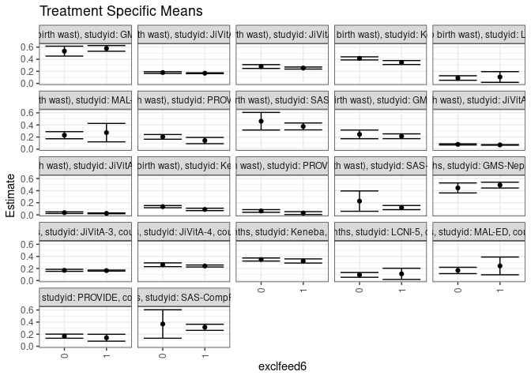

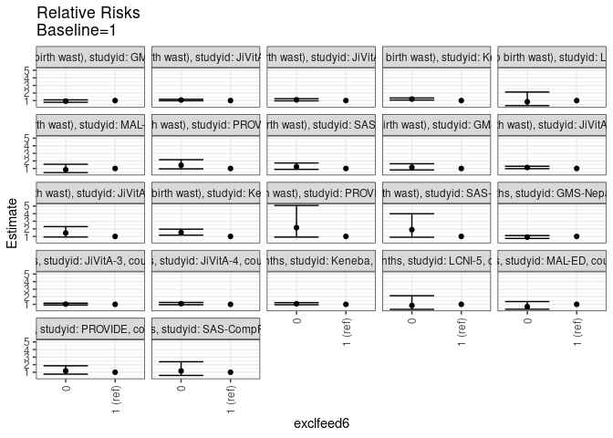

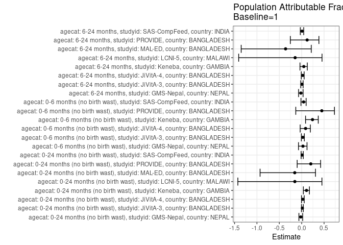

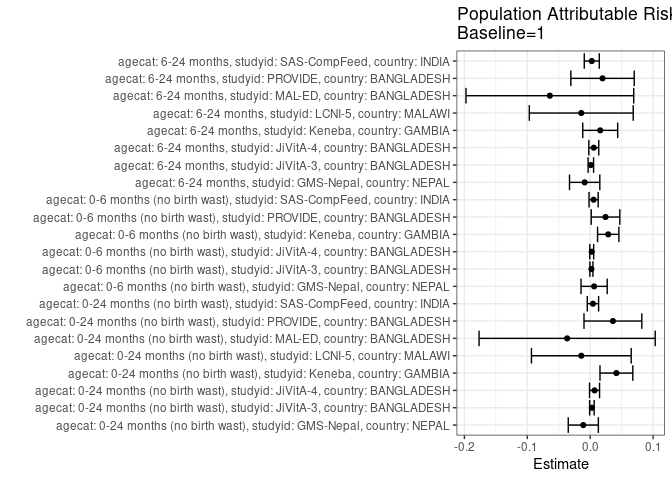

## Results Table

### Parameter: TSM

| agecat | studyid | country | intervention_level | baseline_level | estimate | ci_lower | ci_upper |
| --- | --- | --- | --- | --- | --- | --- | --- |
| 0-24 months (no birth wast) | GMS-Nepal | NEPAL | 1 | NA | 0.5788382 | 0.5316132 | 0.6260632 |
| 0-24 months (no birth wast) | GMS-Nepal | NEPAL | 0 | NA | 0.5338501 | 0.4519488 | 0.6157513 |
| 0-24 months (no birth wast) | JiVitA-3 | BANGLADESH | 1 | NA | 0.1682314 | 0.1610541 | 0.1754087 |
| 0-24 months (no birth wast) | JiVitA-3 | BANGLADESH | 0 | NA | 0.1800070 | 0.1658294 | 0.1941845 |
| 0-24 months (no birth wast) | JiVitA-4 | BANGLADESH | 1 | NA | 0.2542244 | 0.2373559 | 0.2710928 |
| 0-24 months (no birth wast) | JiVitA-4 | BANGLADESH | 0 | NA | 0.2789427 | 0.2476478 | 0.3102375 |
| 0-24 months (no birth wast) | Keneba | GAMBIA | 1 | NA | 0.3451844 | 0.3127437 | 0.3776251 |
| 0-24 months (no birth wast) | Keneba | GAMBIA | 0 | NA | 0.4136244 | 0.3879376 | 0.4393111 |
| 0-24 months (no birth wast) | LCNI-5 | MALAWI | 1 | NA | 0.1063830 | 0.0180722 | 0.1946938 |
| 0-24 months (no birth wast) | LCNI-5 | MALAWI | 0 | NA | 0.0892857 | 0.0518739 | 0.1266975 |
| 0-24 months (no birth wast) | MAL-ED | BANGLADESH | 1 | NA | 0.2727273 | 0.1204490 | 0.4250056 |
| 0-24 months (no birth wast) | MAL-ED | BANGLADESH | 0 | NA | 0.2300000 | 0.1715511 | 0.2884489 |
| 0-24 months (no birth wast) | PROVIDE | BANGLADESH | 1 | NA | 0.1415288 | 0.0899381 | 0.1931195 |
| 0-24 months (no birth wast) | PROVIDE | BANGLADESH | 0 | NA | 0.2027873 | 0.1642420 | 0.2413326 |
| 0-24 months (no birth wast) | SAS-CompFeed | INDIA | 1 | NA | 0.3749192 | 0.3179202 | 0.4319182 |
| 0-24 months (no birth wast) | SAS-CompFeed | INDIA | 0 | NA | 0.4616077 | 0.3160035 | 0.6072120 |
| 0-6 months (no birth wast) | GMS-Nepal | NEPAL | 1 | NA | 0.2125623 | 0.1727102 | 0.2524144 |
| 0-6 months (no birth wast) | GMS-Nepal | NEPAL | 0 | NA | 0.2441166 | 0.1724361 | 0.3157971 |
| 0-6 months (no birth wast) | JiVitA-3 | BANGLADESH | 1 | NA | 0.0700053 | 0.0648890 | 0.0751217 |
| 0-6 months (no birth wast) | JiVitA-3 | BANGLADESH | 0 | NA | 0.0787196 | 0.0689046 | 0.0885346 |
| 0-6 months (no birth wast) | JiVitA-4 | BANGLADESH | 1 | NA | 0.0250507 | 0.0189357 | 0.0311658 |
| 0-6 months (no birth wast) | JiVitA-4 | BANGLADESH | 0 | NA | 0.0363225 | 0.0228536 | 0.0497914 |
| 0-6 months (no birth wast) | Keneba | GAMBIA | 1 | NA | 0.0899379 | 0.0701138 | 0.1097620 |
| 0-6 months (no birth wast) | Keneba | GAMBIA | 0 | NA | 0.1358219 | 0.1178330 | 0.1538108 |
| 0-6 months (no birth wast) | PROVIDE | BANGLADESH | 1 | NA | 0.0298507 | 0.0063076 | 0.0533939 |
| 0-6 months (no birth wast) | PROVIDE | BANGLADESH | 0 | NA | 0.0643154 | 0.0423992 | 0.0862315 |
| 0-6 months (no birth wast) | SAS-CompFeed | INDIA | 1 | NA | 0.1204819 | 0.0857775 | 0.1551864 |
| 0-6 months (no birth wast) | SAS-CompFeed | INDIA | 0 | NA | 0.2272727 | 0.0595457 | 0.3949997 |
| 6-24 months | GMS-Nepal | NEPAL | 1 | NA | 0.4917826 | 0.4438360 | 0.5397292 |
| 6-24 months | GMS-Nepal | NEPAL | 0 | NA | 0.4446611 | 0.3620162 | 0.5273061 |
| 6-24 months | JiVitA-3 | BANGLADESH | 1 | NA | 0.1650396 | 0.1561760 | 0.1739031 |
| 6-24 months | JiVitA-3 | BANGLADESH | 0 | NA | 0.1694196 | 0.1528684 | 0.1859708 |
| 6-24 months | JiVitA-4 | BANGLADESH | 1 | NA | 0.2406443 | 0.2239586 | 0.2573299 |
| 6-24 months | JiVitA-4 | BANGLADESH | 0 | NA | 0.2614224 | 0.2302843 | 0.2925604 |
| 6-24 months | Keneba | GAMBIA | 1 | NA | 0.3238435 | 0.2897075 | 0.3579795 |
| 6-24 months | Keneba | GAMBIA | 0 | NA | 0.3481045 | 0.3229439 | 0.3732652 |
| 6-24 months | LCNI-5 | MALAWI | 1 | NA | 0.1111111 | 0.0191112 | 0.2031111 |
| 6-24 months | LCNI-5 | MALAWI | 0 | NA | 0.0938967 | 0.0546489 | 0.1331445 |
| 6-24 months | MAL-ED | BANGLADESH | 1 | NA | 0.2424242 | 0.0958903 | 0.3889582 |
| 6-24 months | MAL-ED | BANGLADESH | 0 | NA | 0.1675127 | 0.1152522 | 0.2197732 |
| 6-24 months | PROVIDE | BANGLADESH | 1 | NA | 0.1413970 | 0.0845987 | 0.1981954 |
| 6-24 months | PROVIDE | BANGLADESH | 0 | NA | 0.1669788 | 0.1330725 | 0.2008850 |
| 6-24 months | SAS-CompFeed | INDIA | 1 | NA | 0.3140704 | 0.2638452 | 0.3642955 |
| 6-24 months | SAS-CompFeed | INDIA | 0 | NA | 0.3684211 | 0.1333387 | 0.6035034 |

### Parameter: E(Y)

| agecat | studyid | country | intervention_level | baseline_level | estimate | ci_lower | ci_upper |
| --- | --- | --- | --- | --- | --- | --- | --- |
| 0-24 months (no birth wast) | GMS-Nepal | NEPAL | NA | NA | 0.5678571 | 0.5267918 | 0.6089225 |
| 0-24 months (no birth wast) | JiVitA-3 | BANGLADESH | NA | NA | 0.1708796 | 0.1645476 | 0.1772116 |
| 0-24 months (no birth wast) | JiVitA-4 | BANGLADESH | NA | NA | 0.2611182 | 0.2462845 | 0.2759518 |
| 0-24 months (no birth wast) | Keneba | GAMBIA | NA | NA | 0.3867925 | 0.3665564 | 0.4070285 |
| 0-24 months (no birth wast) | LCNI-5 | MALAWI | NA | NA | 0.0922509 | 0.0577338 | 0.1267680 |
| 0-24 months (no birth wast) | MAL-ED | BANGLADESH | NA | NA | 0.2360515 | 0.1814079 | 0.2906951 |
| 0-24 months (no birth wast) | PROVIDE | BANGLADESH | NA | NA | 0.1775837 | 0.1489858 | 0.2061816 |
| 0-24 months (no birth wast) | SAS-CompFeed | INDIA | NA | NA | 0.3792325 | 0.3255512 | 0.4329138 |
| 0-6 months (no birth wast) | GMS-Nepal | NEPAL | NA | NA | 0.2187500 | 0.1839790 | 0.2535210 |
| 0-6 months (no birth wast) | JiVitA-3 | BANGLADESH | NA | NA | 0.0719114 | 0.0672720 | 0.0765508 |
| 0-6 months (no birth wast) | JiVitA-4 | BANGLADESH | NA | NA | 0.0274331 | 0.0219967 | 0.0328694 |
| 0-6 months (no birth wast) | Keneba | GAMBIA | NA | NA | 0.1185520 | 0.1050716 | 0.1320324 |
| 0-6 months (no birth wast) | PROVIDE | BANGLADESH | NA | NA | 0.0541728 | 0.0371844 | 0.0711612 |
| 0-6 months (no birth wast) | SAS-CompFeed | INDIA | NA | NA | 0.1258581 | 0.0910745 | 0.1606418 |
| 6-24 months | GMS-Nepal | NEPAL | NA | NA | 0.4829443 | 0.4414080 | 0.5244807 |
| 6-24 months | JiVitA-3 | BANGLADESH | NA | NA | 0.1660459 | 0.1583106 | 0.1737812 |
| 6-24 months | JiVitA-4 | BANGLADESH | NA | NA | 0.2463096 | 0.2316309 | 0.2609882 |
| 6-24 months | Keneba | GAMBIA | NA | NA | 0.3397129 | 0.3194033 | 0.3600225 |
| 6-24 months | LCNI-5 | MALAWI | NA | NA | 0.0968992 | 0.0607324 | 0.1330660 |
| 6-24 months | MAL-ED | BANGLADESH | NA | NA | 0.1782609 | 0.1286901 | 0.2278316 |
| 6-24 months | PROVIDE | BANGLADESH | NA | NA | 0.1609756 | 0.1319065 | 0.1900447 |
| 6-24 months | SAS-CompFeed | INDIA | NA | NA | 0.3165468 | 0.2711185 | 0.3619751 |

### Parameter: RR

| agecat | studyid | country | intervention_level | baseline_level | estimate | ci_lower | ci_upper |
| --- | --- | --- | --- | --- | --- | --- | --- |
| 0-24 months (no birth wast) | GMS-Nepal | NEPAL | 1 | 1 | 1.0000000 | 1.0000000 | 1.000000 |
| 0-24 months (no birth wast) | GMS-Nepal | NEPAL | 0 | 1 | 0.9222786 | 0.7759829 | 1.096155 |
| 0-24 months (no birth wast) | JiVitA-3 | BANGLADESH | 1 | 1 | 1.0000000 | 1.0000000 | 1.000000 |
| 0-24 months (no birth wast) | JiVitA-3 | BANGLADESH | 0 | 1 | 1.0699961 | 0.9773432 | 1.171433 |
| 0-24 months (no birth wast) | JiVitA-4 | BANGLADESH | 1 | 1 | 1.0000000 | 1.0000000 | 1.000000 |
| 0-24 months (no birth wast) | JiVitA-4 | BANGLADESH | 0 | 1 | 1.0972303 | 0.9644336 | 1.248312 |
| 0-24 months (no birth wast) | Keneba | GAMBIA | 1 | 1 | 1.0000000 | 1.0000000 | 1.000000 |
| 0-24 months (no birth wast) | Keneba | GAMBIA | 0 | 1 | 1.1982707 | 1.0713779 | 1.340193 |
| 0-24 months (no birth wast) | LCNI-5 | MALAWI | 1 | 1 | 1.0000000 | 1.0000000 | 1.000000 |
| 0-24 months (no birth wast) | LCNI-5 | MALAWI | 0 | 1 | 0.8392857 | 0.3311837 | 2.126918 |
| 0-24 months (no birth wast) | MAL-ED | BANGLADESH | 1 | 1 | 1.0000000 | 1.0000000 | 1.000000 |
| 0-24 months (no birth wast) | MAL-ED | BANGLADESH | 0 | 1 | 0.8433333 | 0.4566411 | 1.557484 |
| 0-24 months (no birth wast) | PROVIDE | BANGLADESH | 1 | 1 | 1.0000000 | 1.0000000 | 1.000000 |
| 0-24 months (no birth wast) | PROVIDE | BANGLADESH | 0 | 1 | 1.4328342 | 0.9497272 | 2.161688 |
| 0-24 months (no birth wast) | SAS-CompFeed | INDIA | 1 | 1 | 1.0000000 | 1.0000000 | 1.000000 |
| 0-24 months (no birth wast) | SAS-CompFeed | INDIA | 0 | 1 | 1.2312191 | 0.8795362 | 1.723523 |
| 0-6 months (no birth wast) | GMS-Nepal | NEPAL | 1 | 1 | 1.0000000 | 1.0000000 | 1.000000 |
| 0-6 months (no birth wast) | GMS-Nepal | NEPAL | 0 | 1 | 1.1484471 | 0.8102951 | 1.627717 |
| 0-6 months (no birth wast) | JiVitA-3 | BANGLADESH | 1 | 1 | 1.0000000 | 1.0000000 | 1.000000 |
| 0-6 months (no birth wast) | JiVitA-3 | BANGLADESH | 0 | 1 | 1.1244799 | 0.9763783 | 1.295046 |
| 0-6 months (no birth wast) | JiVitA-4 | BANGLADESH | 1 | 1 | 1.0000000 | 1.0000000 | 1.000000 |
| 0-6 months (no birth wast) | JiVitA-4 | BANGLADESH | 0 | 1 | 1.4499576 | 0.9176976 | 2.290926 |
| 0-6 months (no birth wast) | Keneba | GAMBIA | 1 | 1 | 1.0000000 | 1.0000000 | 1.000000 |
| 0-6 months (no birth wast) | Keneba | GAMBIA | 0 | 1 | 1.5101745 | 1.1685923 | 1.951602 |
| 0-6 months (no birth wast) | PROVIDE | BANGLADESH | 1 | 1 | 1.0000000 | 1.0000000 | 1.000000 |
| 0-6 months (no birth wast) | PROVIDE | BANGLADESH | 0 | 1 | 2.1545643 | 0.9124937 | 5.087320 |
| 0-6 months (no birth wast) | SAS-CompFeed | INDIA | 1 | 1 | 1.0000000 | 1.0000000 | 1.000000 |
| 0-6 months (no birth wast) | SAS-CompFeed | INDIA | 0 | 1 | 1.8863636 | 0.8915751 | 3.991103 |
| 6-24 months | GMS-Nepal | NEPAL | 1 | 1 | 1.0000000 | 1.0000000 | 1.000000 |
| 6-24 months | GMS-Nepal | NEPAL | 0 | 1 | 0.9041823 | 0.7337479 | 1.114205 |
| 6-24 months | JiVitA-3 | BANGLADESH | 1 | 1 | 1.0000000 | 1.0000000 | 1.000000 |
| 6-24 months | JiVitA-3 | BANGLADESH | 0 | 1 | 1.0265391 | 0.9172383 | 1.148865 |
| 6-24 months | JiVitA-4 | BANGLADESH | 1 | 1 | 1.0000000 | 1.0000000 | 1.000000 |
| 6-24 months | JiVitA-4 | BANGLADESH | 0 | 1 | 1.0863437 | 0.9479893 | 1.244890 |
| 6-24 months | Keneba | GAMBIA | 1 | 1 | 1.0000000 | 1.0000000 | 1.000000 |
| 6-24 months | Keneba | GAMBIA | 0 | 1 | 1.0749160 | 0.9466365 | 1.220579 |
| 6-24 months | LCNI-5 | MALAWI | 1 | 1 | 1.0000000 | 1.0000000 | 1.000000 |
| 6-24 months | LCNI-5 | MALAWI | 0 | 1 | 0.8450704 | 0.3342527 | 2.136539 |
| 6-24 months | MAL-ED | BANGLADESH | 1 | 1 | 1.0000000 | 1.0000000 | 1.000000 |
| 6-24 months | MAL-ED | BANGLADESH | 0 | 1 | 0.6909898 | 0.3499915 | 1.364225 |
| 6-24 months | PROVIDE | BANGLADESH | 1 | 1 | 1.0000000 | 1.0000000 | 1.000000 |
| 6-24 months | PROVIDE | BANGLADESH | 0 | 1 | 1.1809212 | 0.7526646 | 1.852850 |
| 6-24 months | SAS-CompFeed | INDIA | 1 | 1 | 1.0000000 | 1.0000000 | 1.000000 |
| 6-24 months | SAS-CompFeed | INDIA | 0 | 1 | 1.1730526 | 0.5767231 | 2.385985 |

### Parameter: PAR

| agecat | studyid | country | intervention_level | baseline_level | estimate | ci_lower | ci_upper |
| --- | --- | --- | --- | --- | --- | --- | --- |
| 0-24 months (no birth wast) | GMS-Nepal | NEPAL | 1 | NA | -0.0109810 | -0.0349063 | 0.0129442 |
| 0-24 months (no birth wast) | JiVitA-3 | BANGLADESH | 1 | NA | 0.0026482 | -0.0009243 | 0.0062207 |
| 0-24 months (no birth wast) | JiVitA-4 | BANGLADESH | 1 | NA | 0.0068938 | -0.0010644 | 0.0148520 |
| 0-24 months (no birth wast) | Keneba | GAMBIA | 1 | NA | 0.0416081 | 0.0155202 | 0.0676959 |
| 0-24 months (no birth wast) | LCNI-5 | MALAWI | 1 | NA | -0.0141321 | -0.0934107 | 0.0651466 |
| 0-24 months (no birth wast) | MAL-ED | BANGLADESH | 1 | NA | -0.0366758 | -0.1766977 | 0.1033462 |
| 0-24 months (no birth wast) | PROVIDE | BANGLADESH | 1 | NA | 0.0360549 | -0.0098936 | 0.0820034 |
| 0-24 months (no birth wast) | SAS-CompFeed | INDIA | 1 | NA | 0.0043133 | -0.0046855 | 0.0133121 |
| 0-6 months (no birth wast) | GMS-Nepal | NEPAL | 1 | NA | 0.0061877 | -0.0146199 | 0.0269953 |
| 0-6 months (no birth wast) | JiVitA-3 | BANGLADESH | 1 | NA | 0.0019061 | -0.0005059 | 0.0043181 |
| 0-6 months (no birth wast) | JiVitA-4 | BANGLADESH | 1 | NA | 0.0023823 | -0.0007213 | 0.0054859 |
| 0-6 months (no birth wast) | Keneba | GAMBIA | 1 | NA | 0.0286142 | 0.0116611 | 0.0455672 |
| 0-6 months (no birth wast) | PROVIDE | BANGLADESH | 1 | NA | 0.0243220 | 0.0015921 | 0.0470519 |
| 0-6 months (no birth wast) | SAS-CompFeed | INDIA | 1 | NA | 0.0053762 | -0.0018898 | 0.0126422 |
| 6-24 months | GMS-Nepal | NEPAL | 1 | NA | -0.0088383 | -0.0329338 | 0.0152572 |
| 6-24 months | JiVitA-3 | BANGLADESH | 1 | NA | 0.0010063 | -0.0033327 | 0.0053453 |
| 6-24 months | JiVitA-4 | BANGLADESH | 1 | NA | 0.0056653 | -0.0022185 | 0.0135491 |
| 6-24 months | Keneba | GAMBIA | 1 | NA | 0.0158694 | -0.0119007 | 0.0436395 |
| 6-24 months | LCNI-5 | MALAWI | 1 | NA | -0.0142119 | -0.0967920 | 0.0683682 |
| 6-24 months | MAL-ED | BANGLADESH | 1 | NA | -0.0641634 | -0.1974596 | 0.0691328 |
| 6-24 months | PROVIDE | BANGLADESH | 1 | NA | 0.0195786 | -0.0307793 | 0.0699365 |
| 6-24 months | SAS-CompFeed | INDIA | 1 | NA | 0.0024764 | -0.0094430 | 0.0143959 |

### Parameter: PAF

| agecat | studyid | country | intervention_level | baseline_level | estimate | ci_lower | ci_upper |
| --- | --- | --- | --- | --- | --- | --- | --- |
| 0-24 months (no birth wast) | GMS-Nepal | NEPAL | 1 | NA | -0.0193377 | -0.0623985 | 0.0219778 |
| 0-24 months (no birth wast) | JiVitA-3 | BANGLADESH | 1 | NA | 0.0154975 | -0.0056231 | 0.0361745 |
| 0-24 months (no birth wast) | JiVitA-4 | BANGLADESH | 1 | NA | 0.0264011 | -0.0046041 | 0.0564494 |
| 0-24 months (no birth wast) | Keneba | GAMBIA | 1 | NA | 0.1075721 | 0.0374747 | 0.1725645 |
| 0-24 months (no birth wast) | LCNI-5 | MALAWI | 1 | NA | -0.1531915 | -1.4265796 | 0.4519650 |
| 0-24 months (no birth wast) | MAL-ED | BANGLADESH | 1 | NA | -0.1553719 | -0.9300888 | 0.3083820 |
| 0-24 months (no birth wast) | PROVIDE | BANGLADESH | 1 | NA | 0.2030305 | -0.1009042 | 0.4230557 |
| 0-24 months (no birth wast) | SAS-CompFeed | INDIA | 1 | NA | 0.0113737 | -0.0131809 | 0.0353333 |
| 0-6 months (no birth wast) | GMS-Nepal | NEPAL | 1 | NA | 0.0282865 | -0.0715781 | 0.1188443 |
| 0-6 months (no birth wast) | JiVitA-3 | BANGLADESH | 1 | NA | 0.0265059 | -0.0075730 | 0.0594323 |
| 0-6 months (no birth wast) | JiVitA-4 | BANGLADESH | 1 | NA | 0.0868408 | -0.0340459 | 0.1935950 |
| 0-6 months (no birth wast) | Keneba | GAMBIA | 1 | NA | 0.2413636 | 0.0863497 | 0.3700772 |
| 0-6 months (no birth wast) | PROVIDE | BANGLADESH | 1 | NA | 0.4489714 | -0.1322414 | 0.7318305 |
| 0-6 months (no birth wast) | SAS-CompFeed | INDIA | 1 | NA | 0.0427163 | -0.0166271 | 0.0985957 |
| 6-24 months | GMS-Nepal | NEPAL | 1 | NA | -0.0183008 | -0.0694681 | 0.0304184 |
| 6-24 months | JiVitA-3 | BANGLADESH | 1 | NA | 0.0060604 | -0.0204189 | 0.0318526 |
| 6-24 months | JiVitA-4 | BANGLADESH | 1 | NA | 0.0230008 | -0.0095721 | 0.0545228 |
| 6-24 months | Keneba | GAMBIA | 1 | NA | 0.0467142 | -0.0386413 | 0.1250552 |
| 6-24 months | LCNI-5 | MALAWI | 1 | NA | -0.1466667 | -1.4083049 | 0.4540374 |
| 6-24 months | MAL-ED | BANGLADESH | 1 | NA | -0.3599409 | -1.3519971 | 0.2136729 |
| 6-24 months | PROVIDE | BANGLADESH | 1 | NA | 0.1216244 | -0.2535997 | 0.3845375 |
| 6-24 months | SAS-CompFeed | INDIA | 1 | NA | 0.0078232 | -0.0309120 | 0.0451030 |